# CMPT 459.1-19. Programming Assignment 2

FIFA 19 Players

Felix Sam

### Introduction

The data has detailed attributes for every player registered in the latest edition of FIFA 19 database, obtained scraping the website “sofifa.com”. Each instance is a different player, and the attributes give basic information about the players and their football skills. Basic pre-processing was done and Goal Keepers were removed for this assignment.

Please look here for the original data overview and attributes’ descriptions:

- https://www.kaggle.com/karangadiya/fifa19

And here to get a better view of the information:

- https://sofifa.com/

### Reading the data

Assume you want to decide whether to put each player on Defense or not, based on individual metrics. Attributes that make sense for such task were selected and data was already split into train and test datasets. Train was balanced for training purposes. Please see that test dataset is not balanced (keeps original balance).

```r
train <- read.csv('fifa-train.csv')
test <- read.csv('fifa-test.csv')
table(train$Defense)
```

```
  No  Yes
4483 4485
```

```r
table(test$Defense)
```

```
  No  Yes
 675 1121
```

### Decision Trees

“caret” is a R package that encapsulates several methods from other packages. Below we’ll use “rpart” to build a Decision Tree on train dataset to classify “Defense” using all other attributes. We’ll see more on trControl later.

```r
library(caret)
set.seed(1)
dt <- train(Defense ~ ., # Formula
            data = train, # Data
            method = "rpart", # Method
            trControl = trainControl(method = "none")) # Control options
```

We can see the resulting model with:

```r
dt$finalModel
```

```
n= 8968

node), split, n, loss, yval, (yprob)
      * denotes terminal node

1) root 8968 4483 Yes (0.4998885 0.5001115) *
```

Basically it’s just the root node classifying everything as “Yes”. Let’s find out what’s going on.

The method below shows what parameters “caret” package chose to optimize “rpart” within the “train” function.

```r
modelLookup("rpart")
```

|  | model | parameter | label | forReg | forClass | probModel |
| --- | --- | --- | --- | --- | --- | --- |
| 1 | rpart | cp | Complexity Parameter | TRUE | TRUE | TRUE |

So, it’s only optimizing the complexity parameter `cp`. “rpart” actually incorporates pruning during the learning phase, so that any split that does not decrease the overall lack of fit by a factor of `cp` is not even attempted.

Now, the result below shows the values used in the parameters optimized by “caret” to build the model:

```r
dt$bestTune
```

| cp |
| --- |
| 0.4800357 |

So we can see it only tried `cp = 0.4800357`.

**[Task 1]** (5 marks): Please answer the following question. Does the finding above about `cp` explains the resulting model obtained? Justify.

- Yes cp determines the cost of adding another node to the tree. It determines when the splitting stops.
- Since cp is relatively high at 0.48, the tree would not split if the overall lack of fit from the resulting split decreases by 0.48
- It explains why the tree only contains the root node

To tell caret’s “train” function to try different values of the parameters it chose to optimize, we can create a grid and pass it to the “train” function. Let’s try the following `cp` value: 0.01

```r
dt <- train(Defense ~ .,
               data = train,
               method = "rpart",
               tuneGrid = expand.grid(cp = 0.01), # GRID for parameters 'caret' optimizes
               trControl = trainControl(method = "none"))
```

Here’s the resulting model:

```r
dt$finalModel
```

```
n= 8968

node), split, n, loss, yval, (yprob)
      * denotes terminal node

 1) root 8968 4483 Yes (0.4998885 0.5001115)
   2) SlidingTackle< 35.5 5152 1500 No (0.7088509 0.2911491)
     4) HeadingAccuracy>=48.5 3808  744 No (0.8046218 0.1953782) *
     5) HeadingAccuracy< 48.5 1344  588 Yes (0.4375000 0.5625000)
      10) LongPassing< 42.5 269   60 No (0.7769517 0.2230483) *
      11) LongPassing>=42.5 1075  379 Yes (0.3525581 0.6474419) *
   3) SlidingTackle>=35.5 3816  831 Yes (0.2177673 0.7822327)
     6) LongPassing< 55.5 804  330 Yes (0.4104478 0.5895522)
      12) HeadingAccuracy>=50.5 347  122 No (0.6484150 0.3515850) *
      13) HeadingAccuracy< 50.5 457  105 Yes (0.2297593 0.7702407) *
     7) LongPassing>=55.5 3012  501 Yes (0.1663347 0.8336653) *
```

Now, let’s plot the tree:

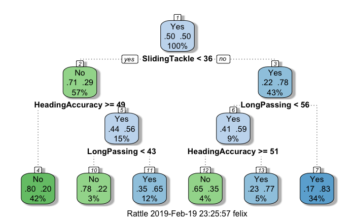

```r
library(rattle)
fancyRpartPlot(dt$finalModel)
```

And finally get the confusion matrix on the train dataset:

```r
confusionMatrix(predict(dt), train$Defense, positive = 'Yes')
```

```
Confusion Matrix and Statistics

          Reference
Prediction   No  Yes
       No  3498  926
       Yes  985 3559

               Accuracy : 0.7869
                 95% CI : (0.7783, 0.7953)
    No Information Rate : 0.5001
    P-Value [Acc > NIR] : <2e-16

                  Kappa : 0.5738
 Mcnemar's Test P-Value : 0.1846

            Sensitivity : 0.7935
            Specificity : 0.7803
         Pos Pred Value : 0.7832
         Neg Pred Value : 0.7907
             Prevalence : 0.5001
         Detection Rate : 0.3969
   Detection Prevalence : 0.5067
      Balanced Accuracy : 0.7869

       'Positive' Class : Yes
```

**[Task 2]** (1 mark): Please answer the following question. What’s the training accuracy for the model?

- 78.69% (0.7869)

We can also change parameters that “caret” did not choose to optimize but the original function (“rpart” in this case) uses. To do that, we just pass the parameters directly to caret’s “train” function and it will go to “rpart”.

So if we do `?rpart` we’ll see it uses the “parms” argument, where we can change the quality measure for splitting. Its default is “gini” (for Gini Index), so let’s change it and use “information” (for Information Gain).

```r
set.seed(1)
dt <- train(Defense ~ .,
            data = train,
            method = "rpart",
            tuneGrid = expand.grid(cp = 0.01),
            trControl = trainControl(method = "none"),
            parms = list(split = "information") # "gini" is the default
            )
```

Let’s see the confusion matrix for training data:

```r
confusionMatrix(predict(dt), as.factor(train$Defense), positive = 'Yes')
```

```
Confusion Matrix and Statistics

          Reference
Prediction   No  Yes
       No  3462  836
       Yes 1021 3649

               Accuracy : 0.7929
                 95% CI : (0.7844, 0.8013)
    No Information Rate : 0.5001
    P-Value [Acc > NIR] : < 2.2e-16

                  Kappa : 0.5859
 Mcnemar's Test P-Value : 1.956e-05

            Sensitivity : 0.8136
            Specificity : 0.7723
         Pos Pred Value : 0.7814
         Neg Pred Value : 0.8055
             Prevalence : 0.5001
         Detection Rate : 0.4069
   Detection Prevalence : 0.5207
      Balanced Accuracy : 0.7929

       'Positive' Class : Yes
```

And plot the tree:

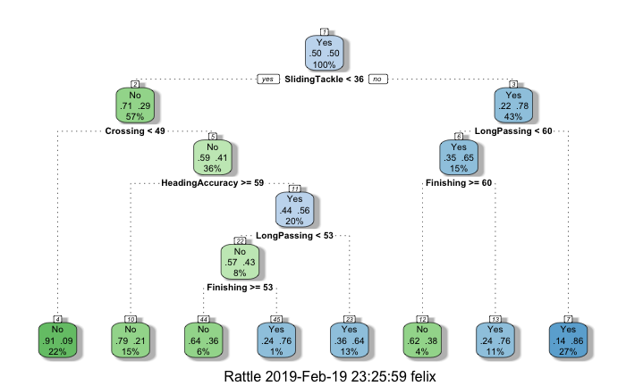

```r
fancyRpartPlot(dt$finalModel)
```

**[Task 3]** (10 marks): Please answer the following questions:

- What’s the training accuracy for the model now? Is it better or worse than before?
- 79.29%. It is better than before (78.69% with gini-index)
- Is the tree more or less complex overall?
- Overall the tree is more complex.
- It includes the Finishing and crossing attributes in the tree
- Explain possible reasons for the difference observed in complexity observerd in the trees.
- Information Gain favors attributes that have a wide range of values.
- When calculating InformationGain, attributes with a wide range of values will be highly branched.
- In general each branch of the attribute will have an smaller entropy closer to 0 which would lead to high information gain

## This can lead to the attribute to be chosen as an attribute to split the tree which can also lead to overfitting,explaining the higher accuracy compared to using gini-index.

So far we’ve used a fixed `cp`. Since “caret” chose `cp` to optimize, we can try several values at once. “caret” will then use some resampling method to get the `cp` with best results.

For example, let’s try `cp` values of 0.60, 0.40, 0.10, 0.05, 0.01 on the `tuneGrid` and use Accuracy from **10-fold Cross Validation** to choose the best one. To add such option we change the `trControl` on “train” function.

```r
set.seed(1)
dt <- train(Defense ~ .,
            data = train,
            method = "rpart",
            tuneGrid = expand.grid(cp = c(0.60, 0.40, 0.10, 0.05, 0.01)),
            parms = list(split = "gini"),
            trControl = trainControl(method = "cv", number = 10) # Add Cross-Validation, 10 folds
            )
```

Let’s see the modeling results:

```r
dt
```

```
CART

8968 samples
  36 predictor
   2 classes: 'No', 'Yes'

No pre-processing
Resampling: Cross-Validated (10 fold)
Summary of sample sizes: 8070, 8071, 8072, 8070, 8071, 8071, ...
Resampling results across tuning parameters:

  cp    Accuracy   Kappa
  0.01  0.7827855  0.5655624
  0.05  0.7395188  0.4790486
  0.10  0.7395188  0.4790486
  0.40  0.7395188  0.4790486
  0.60  0.5001115  0.0000000

Accuracy was used to select the optimal model using the largest value.
The final value used for the model was cp = 0.01.
```

It shows the `cp` chosen as the best (`0.01`), and looking at the accuracy (from 10-fold cross validation) for that `cp` we can see it is `0.7827855`.

We can plot the results for each `cp` tested:

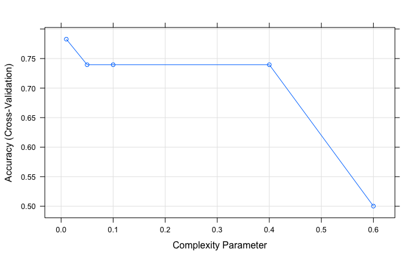

```r
plot(dt)
```

And see the tree:

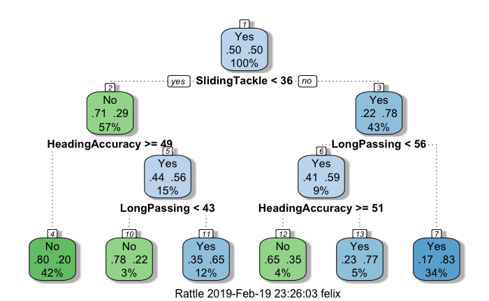

```r
fancyRpartPlot(dt$finalModel)
```

**[Task 4]** (5 marks): Please answer the following questions.

- Comparing training accuracy with 10-fold CV, does the model seem to be overfitting?
- No, the accuracy from 10-fold CV with cp = 0.01(0.7827855) is around the same accuracy as cp = 0.01 without 10-fold CV(0.7869).
- The training accuracy with 10-fold CV is also smaller.
- So it does not appear that the model is overfitting.
- Does it make sense to be smaller? Justify.
- Yes, because cross validation reduces overfitting
- By splitting the training set into smaller subsets, you can reduce overfitting because the model trained on one subset can be tested on a different subset, which helps detect if a model works well on the trained data but not the validation data.

**[Task 5]** (8 marks): Now using the “train” function, test changing values of `cp` (optimized by “caret”" directly) and other parameters from “rpart” (see `?rpart` for help). Try to get the best model you can, considering the 10-Fold CV Accuracy.

```r
set.seed(1)
dt <- train(
            Defense ~ .,
            data = train,
            method = "rpart",
            tuneGrid = expand.grid(cp = c(0.60, 0.40, 0.10, 0.05, 0.01)),
            parms = list(split=c("information","gini")),
            trControl = trainControl(method = "cv", number = 10) # Add Cross-Validation, 10 folds
)
```

Show the results for your modeling:

```r
dt
```

```
CART

8968 samples
  36 predictor
   2 classes: 'No', 'Yes'

No pre-processing
Resampling: Cross-Validated (10 fold)
Summary of sample sizes: 8070, 8071, 8072, 8070, 8071, 8071, ...
Resampling results across tuning parameters:

  cp    Accuracy   Kappa
  0.01  0.7813324  0.5626652
  0.05  0.7400758  0.4801643
  0.10  0.7400758  0.4801643
  0.40  0.7400758  0.4801643
  0.60  0.5001115  0.0000000

Accuracy was used to select the optimal model using the largest value.
The final value used for the model was cp = 0.01.
```

Plot the results for each `cp` tested:

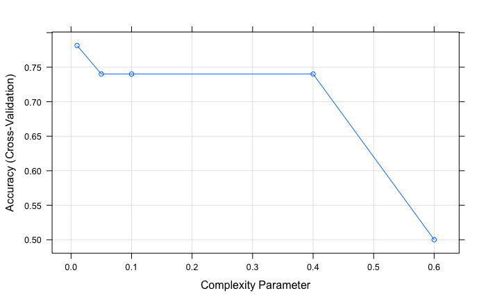

```r
plot(dt)
```

### Logistic Regression

**[Task 6]** (5 marks): Create a logistic regression model using caret’s “train” function with the method “glm” and 10-fold cross validation. Please save the caret’s “train” results on an object “lgr”.

```r
set.seed(1)
lgr <- train(
            Defense ~ .,
            data = train,
            method = "glm",
            trControl = trainControl(method = "cv", number = 10) # Add Cross-Validation, 10 folds
)
```

Show the results for your modeling:

```r
lgr
```

```
Generalized Linear Model

8968 samples
  36 predictor
   2 classes: 'No', 'Yes'

No pre-processing
Resampling: Cross-Validated (10 fold)
Summary of sample sizes: 8070, 8071, 8072, 8070, 8071, 8071, ...
Resampling results:

  Accuracy   Kappa
  0.8123339  0.6246645
```

Let’s see the coefficients of the logistic regression model.

```r
summary(lgr$finalModel)
```

```
Call:
NULL

Deviance Residuals:
    Min       1Q   Median       3Q      Max
-2.6488  -0.5976   0.0870   0.6345   3.5518

Coefficients:
                      Estimate Std. Error z value Pr(>|z|)
(Intercept)         -3.593e+00  1.589e+00  -2.262 0.023717 *
Age                  1.131e-02  9.126e-03   1.240 0.215078
Value               -1.607e-08  9.045e-09  -1.776 0.075658 .
Wage                -1.392e-05  2.488e-06  -5.594 2.21e-08 ***
Height               1.609e-02  8.341e-03   1.929 0.053784 .
Weight              -5.802e-03  3.391e-03  -1.711 0.087073 .
Crossing            -6.267e-03  4.342e-03  -1.443 0.148902
Finishing           -3.071e-02  5.865e-03  -5.237 1.63e-07 ***
HeadingAccuracy     -3.653e-02  3.951e-03  -9.246  < 2e-16 ***
ShortPassing         3.945e-02  8.609e-03   4.583 4.59e-06 ***
Volleys              2.758e-03  4.529e-03   0.609 0.542636
Dribbling           -6.165e-04  8.888e-03  -0.069 0.944701
Curve               -1.424e-02  4.375e-03  -3.255 0.001133 **
FKAccuracy           1.282e-02  3.545e-03   3.615 0.000300 ***
LongPassing          6.933e-02  5.649e-03  12.273  < 2e-16 ***
BallControl         -6.897e-03  1.010e-02  -0.683 0.494605
Acceleration        -1.938e-04  6.638e-03  -0.029 0.976705
SprintSpeed         -1.133e-02  6.161e-03  -1.838 0.066035 .
Agility              5.272e-03  4.905e-03   1.075 0.282439
Reactions           -2.060e-02  6.045e-03  -3.407 0.000657 ***
Balance              8.966e-03  4.781e-03   1.875 0.060752 .
ShotPower            8.465e-03  5.596e-03   1.513 0.130373
Jumping             -1.434e-03  2.871e-03  -0.499 0.617488
Stamina              2.222e-03  3.431e-03   0.648 0.517087
Strength            -1.057e-02  4.097e-03  -2.581 0.009865 **
LongShots            7.818e-04  5.243e-03   0.149 0.881458
Aggression           2.027e-03  2.785e-03   0.728 0.466682
Positioning         -2.225e-02  6.410e-03  -3.471 0.000519 ***
Vision               4.834e-02  6.003e-03   8.053 8.09e-16 ***
Penalties           -1.131e-02  4.214e-03  -2.684 0.007279 **
Composure           -2.278e-02  5.577e-03  -4.085 4.40e-05 ***
Marking              1.682e-02  2.866e-03   5.869 4.38e-09 ***
StandingTackle       1.830e-02  5.337e-03   3.430 0.000603 ***
SlidingTackle       -8.339e-04  5.400e-03  -0.154 0.877275
Release.Clause       1.382e-08  5.267e-09   2.624 0.008696 **
Preferred.FootRight  1.035e-01  6.963e-02   1.486 0.137163
---
Signif. codes:  0 ‘***’ 0.001 ‘**’ 0.01 ‘*’ 0.05 ‘.’ 0.1 ‘ ’ 1

(Dispersion parameter for binomial family taken to be 1)

    Null deviance: 12432.3  on 8967  degrees of freedom
Residual deviance:  7628.1  on 8932  degrees of freedom
AIC: 7700.1

Number of Fisher Scoring iterations: 5
```

**[Task 7]** (10 marks): Look at the coefficients aboce, please answer the following questions: - Based on the coefficients, do you think the model is overfitting? Justify. - Yes, there are alot of attributes that are not statistically significant (P(|z|)>0.05). - The model will try to find a relation between the attribute and the outcome(defense), but it is highly unlikely that there is a relation between the two, leading to overfitting

- Is there anything we can do to improve the model?
- Reduce the number of attributes for training by removing attributes that are not likely to be statisfically significant.